# QuercusHealth AI — 01: Architecture & Domain Shift Analysis

**Goal:** Prove statistically that DeepForest's confidence score distribution collapses on Spanish Dehesa imagery compared to its native NEON domain.

| Section | Content |
| --- | --- |
| §1 | Model architecture inspection |
| §2 | NEON baseline — native domain |
| §3 | Spanish Dehesa — target domain (14 annotated tiles) |
| §4 | Statistical proof of domain shift (KS test + Mann-Whitney U) |
| §5 | Hyperparameter sweep — score_thresh and nms_thresh |

> **No annotations are used in this notebook.** We only look at the model's confidence scores to show it behaves differently across domains — without needing ground truth.

```python
import os
import warnings
warnings.filterwarnings('ignore')

import numpy as np
import pandas as pd
import matplotlib.pyplot as plt
import matplotlib.patches as patches
from pathlib import Path
from PIL import Image
from deepforest import main, get_data, visualize

TEST_DIR = Path('../data/test/images/')
REPORTS  = Path('../reports/')
REPORTS.mkdir(exist_ok=True)

print('Imports OK')
print(f'Test images found: {len(list(TEST_DIR.glob("*.jpg")))}')
```

```
Imports OK
Test images found: 14
```

## §1 — Model Architecture

DeepForest v2.1.0 documentation refers to Faster R-CNN, but the actual implementation uses **RetinaNet** — a one-stage detector with Focal Loss. We verify this by inspection.

```python
model = main.deepforest()
model.load_model()

print(f'Lightning wrapper : {type(model).__name__}')
print(f'Detection model   : {type(model.model).__name__}')

backbone = model.model.backbone
print(f'\n--- Backbone ---')
print(f'  Type                : {type(backbone).__name__}')
print(f'  FPN output channels : {backbone.out_channels}')
print('  Body layers:')
for name, layer in backbone.body.named_children():
    print(f'    {name}: {type(layer).__name__}')

ag = model.model.anchor_generator
print(f'\n--- Anchor Generator ({type(ag).__name__}) ---')
print(f'  Anchors/location: {len(ag.sizes[0]) * len(ag.aspect_ratios[0])}')

total_p     = sum(p.numel() for p in model.model.parameters())
trainable_p = sum(p.numel() for p in model.model.parameters() if p.requires_grad)
print(f'\n--- Parameters ---')
print(f'  Total     : {total_p:,}')
print(f'  Trainable : {trainable_p:,}')

print(f'\n--- Inference thresholds ---')
print(f'  score_thresh : {model.model.score_thresh}')
print(f'  nms_thresh   : {model.model.nms_thresh}')

print('\nARCHITECTURE SUMMARY')
print('  RetinaNet (NOT Faster R-CNN) — ResNet-50 + FPN + Focal Loss')
```

[output not shown]

```
Lightning wrapper : deepforest
Detection model   : RetinaNetHub

--- Backbone ---
  Type                : BackboneWithFPN
  FPN output channels : 256
  Body layers:
    conv1: Conv2d
    bn1: FrozenBatchNorm2d
    relu: ReLU
    maxpool: MaxPool2d
    layer1: Sequential
    layer2: Sequential
    layer3: Sequential
    layer4: Sequential

--- Anchor Generator (AnchorGenerator) ---
  Anchors/location: 9

--- Parameters ---
  Total     : 32,147,949
  Trainable : 31,925,549

--- Inference thresholds ---
  score_thresh : 0.1
  nms_thresh   : 0.05

ARCHITECTURE SUMMARY
  RetinaNet (NOT Faster R-CNN) — ResNet-50 + FPN + Focal Loss
```

### What this tells us

- **RetinaNet** is a one-stage detector: it predicts boxes directly on FPN feature maps.
- **Focal Loss** down-weights easy negatives (background), critical for sparse canopies.
- Pre-trained on NEON — dense North American forests. We measure the transfer gap to Dehesa.

## §2 — NEON Baseline (Native Domain)

```
Detections      : 55
Mean confidence : 0.535
Median          : 0.526
```

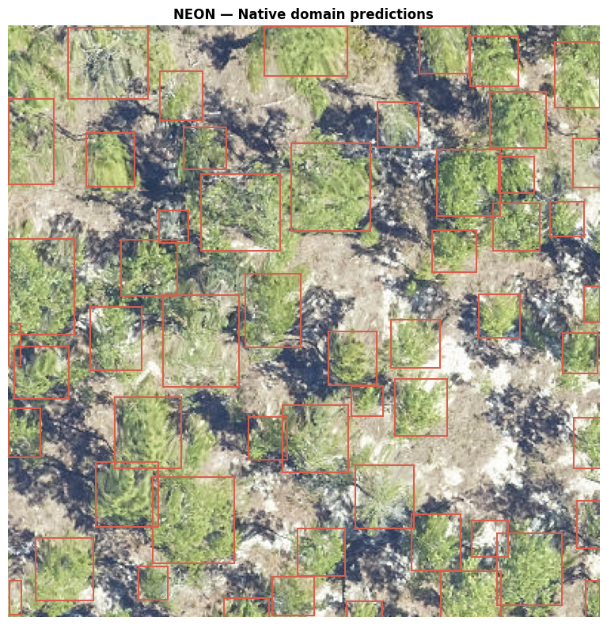

```python
neon_path  = get_data('OSBS_029.png')
neon_boxes = model.predict_image(path=neon_path)

n = len(neon_boxes) if neon_boxes is not None else 0
print(f'Detections      : {n}')
if neon_boxes is not None and len(neon_boxes) > 0:
    print(f'Mean confidence : {neon_boxes["score"].mean():.3f}')
    print(f'Median          : {neon_boxes["score"].median():.3f}')

fig, ax = plt.subplots(figsize=(8, 8))
ax.imshow(np.array(Image.open(neon_path).convert('RGB')))
if neon_boxes is not None:
    for _, row in neon_boxes.iterrows():
        ax.add_patch(patches.Rectangle(
            (row.xmin, row.ymin), row.xmax - row.xmin, row.ymax - row.ymin,
            linewidth=1.5, edgecolor='#d6604d', facecolor='none'))
ax.axis('off')
ax.set_title('NEON — Native domain predictions', fontweight='bold')
plt.tight_layout()
plt.show()
```

## §3 — Spanish Dehesa (Target Domain)

Isolated *Quercus* oaks on bright ochre soil. Crown-to-background ratio as low as 5%. We run the model on all 14 annotated tiles and collect every confidence score.

> Annotations are **not used here** — we only use the images as input.

```python
test_images  = sorted(TEST_DIR.glob('*.jpg'))
print(f'Running inference on {len(test_images)} Dehesa tiles...\n')

dehesa_scores = []
dehesa_boxes_list = []

for img_path in test_images:
    boxes = model.predict_image(path=str(img_path))
    dehesa_boxes_list.append(boxes)
    if boxes is not None and len(boxes) > 0:
        dehesa_scores.extend(boxes['score'].tolist())
    n = len(boxes) if boxes is not None else 0
    print(f'  {img_path.name[:35]}  {n:3d} detections')

dehesa_scores = np.array(dehesa_scores)
print(f'\nTotal detections : {len(dehesa_scores)}')
print(f'Mean confidence  : {dehesa_scores.mean():.3f}')
print(f'Median confidence: {np.median(dehesa_scores):.3f}')
```

```
Running inference on 14 Dehesa tiles...

  img_r01_c04_png.rf.04caf70730942e01   11 detections
  img_r01_c07_png.rf.1fbd4de7d94e3907   14 detections
  img_r01_c08_png.rf.eeb676923ab90fc0   14 detections
  img_r01_c22_png.rf.27b113d6b87d54ae    4 detections
  img_r01_c24_png.rf.bf2e6d2ac1fd3884    8 detections
  img_r01_c29_png.rf.c0f64c85fb4d673d    0 detections
  img_r01_c33_png.rf.3d198ce83f094f03    0 detections
  img_r01_c35_png.rf.7daa3a351b7e1516    1 detections
  img_r02_c04_png.rf.2ff6a4d0f519857b    7 detections
  img_r02_c14_png.rf.b174e7c4fd17f134   19 detections
  img_r02_c24_png.rf.dbf693468e8d83b0    2 detections
  img_r02_c32_png.rf.6938505c6056f57a    6 detections
  img_r02_c33_png.rf.15910a9c26a4c843    2 detections
  img_r02_c34_png.rf.22f8d5a79ce817f3    1 detections

Total detections : 89
Mean confidence  : 0.202
Median confidence: 0.177
```

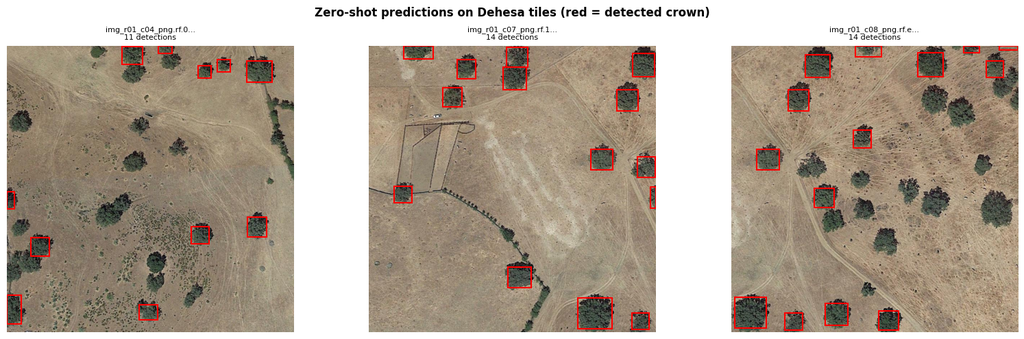

```python
fig, axes = plt.subplots(1, 3, figsize=(16, 5))
for ax, img_path, boxes in zip(axes, test_images[:3], dehesa_boxes_list[:3]):
    img = np.array(Image.open(img_path).convert('RGB'))
    ax.imshow(img)
    if boxes is not None:
        for _, row in boxes.iterrows():
            ax.add_patch(patches.Rectangle(
                (row.xmin, row.ymin), row.xmax - row.xmin, row.ymax - row.ymin,
                linewidth=1.5, edgecolor='red', facecolor='none'))
    n = len(boxes) if boxes is not None else 0
    ax.set_title(f'{img_path.name[:20]}...\n{n} detections', fontsize=8)
    ax.axis('off')
plt.suptitle('Zero-shot predictions on Dehesa tiles (red = detected crown)', fontweight='bold')
plt.tight_layout()
plt.show()
```

## §4 — Statistical Proof of Domain Shift

We compare confidence score distributions between NEON and Dehesa.

```python
from scipy import stats
from scipy.stats import gaussian_kde

neon_scores = neon_boxes['score'].values.astype(float)

print(f'NEON   — n={len(neon_scores):3d}  mean={neon_scores.mean():.3f}  median={np.median(neon_scores):.3f}')
print(f'Dehesa — n={len(dehesa_scores):3d}  mean={dehesa_scores.mean():.3f}  median={np.median(dehesa_scores):.3f}')

mw_stat, mw_p = stats.mannwhitneyu(neon_scores, dehesa_scores, alternative='two-sided')
ks_stat, ks_p = stats.ks_2samp(neon_scores, dehesa_scores)

print(f'\nMann-Whitney U : U={mw_stat:.1f},  p={mw_p:.2e}',
      '-> REJECT H0' if mw_p < 0.05 else '-> fail to reject H0')
print(f'KS test        : D={ks_stat:.4f},  p={ks_p:.2e}',
      '-> REJECT H0' if ks_p < 0.05 else '-> fail to reject H0')
print()
print(f'Interpretation: KS D={ks_stat:.4f} — the two CDFs are separated')
print(f'by {ks_stat*100:.1f}% at their maximum divergence point.')
print('p < 0.0001 on both tests: this gap is not due to chance.')
```

```
NEON   — n= 55  mean=0.535  median=0.526
Dehesa — n= 89  mean=0.202  median=0.177

Mann-Whitney U : U=4806.0,  p=3.15e-22 -> REJECT H0
KS test        : D=0.8641,  p=5.97e-27 -> REJECT H0

Interpretation: KS D=0.8641 — the two CDFs are separated
by 86.4% at their maximum divergence point.
p < 0.0001 on both tests: this gap is not due to chance.
```

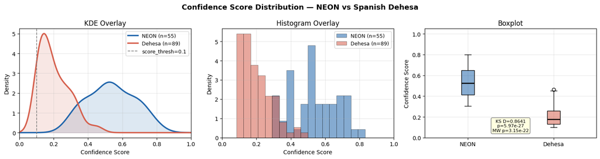

```
Saved: reports/score_distributions.png
```

```python
COLOR  = {'NEON': '#2166ac', 'Dehesa': '#d6604d'}
x_grid = np.linspace(0, 1, 300)

fig, axes = plt.subplots(1, 3, figsize=(15, 4))
fig.suptitle('Confidence Score Distribution — NEON vs Spanish Dehesa',
             fontsize=13, fontweight='bold')

# KDE overlay
ax = axes[0]
for label, scores in [('NEON', neon_scores), ('Dehesa', dehesa_scores)]:
    kde = gaussian_kde(scores, bw_method='silverman')
    ax.plot(x_grid, kde(x_grid), color=COLOR[label], linewidth=2.5,
            label=f'{label} (n={len(scores)})')
    ax.fill_between(x_grid, kde(x_grid), alpha=0.15, color=COLOR[label])
ax.axvline(0.1, color='gray', linestyle='--', linewidth=1.2, label='score_thresh=0.1')
ax.set(xlabel='Confidence Score', ylabel='Density', title='KDE Overlay')
ax.legend(fontsize=9); ax.set_xlim(0, 1); ax.grid(alpha=0.3)

# Histogram
ax = axes[1]
bins = np.linspace(0, 1, 25)
for label, scores in [('NEON', neon_scores), ('Dehesa', dehesa_scores)]:
    ax.hist(scores, bins=bins, alpha=0.55, color=COLOR[label],
            edgecolor='black', linewidth=0.5,
            label=f'{label} (n={len(scores)})', density=True)
ax.set(xlabel='Confidence Score', ylabel='Density', title='Histogram Overlay')
ax.legend(fontsize=9); ax.set_xlim(0, 1); ax.grid(alpha=0.3)

# Boxplot
ax = axes[2]
bp = ax.boxplot([neon_scores, dehesa_scores], labels=['NEON', 'Dehesa'],
                patch_artist=True, medianprops=dict(color='black', linewidth=2))
bp['boxes'][0].set_facecolor(COLOR['NEON'] + '88')
bp['boxes'][1].set_facecolor(COLOR['Dehesa'] + '88')
ax.set(ylabel='Confidence Score', title='Boxplot', ylim=(0, 1.05))
ax.text(1.5, 0.05,
        f'KS D={ks_stat:.4f}\np={ks_p:.2e}\nMW p={mw_p:.2e}',
        ha='center', va='bottom', fontsize=8,
        bbox=dict(boxstyle='round,pad=0.3', facecolor='lightyellow', edgecolor='gray'))
ax.grid(alpha=0.3)

plt.tight_layout()
plt.savefig(REPORTS / 'score_distributions.png', dpi=150, bbox_inches='tight')
plt.show()
print('Saved: reports/score_distributions.png')
```

## §5 — Hyperparameter Sweep

Can we fix the domain shift by tuning the model's thresholds?

- **score_thresh**: detections below this confidence are discarded.
- **nms_thresh**: IoU threshold for Non-Maximum Suppression (removes duplicate boxes).

> **Critical (DeepForest v2.1.0):** must set the threshold on **both** `model.model.score_thresh` AND `model.config['score_thresh']`.

```python
_orig_score = model.model.score_thresh
_orig_nms   = model.model.nms_thresh

# score_thresh sweep
score_rows = []
print('score_thresh sweep across all 14 Dehesa tiles:')
for st in [0.05, 0.1, 0.2, 0.3, 0.4, 0.5]:
    model.model.score_thresh     = st
    model.config['score_thresh'] = st
    all_s = []
    for img_path in test_images:
        b = model.predict_image(path=str(img_path))
        if b is not None and len(b) > 0:
            all_s.extend(b['score'].tolist())
    mean_c = float(np.mean(all_s)) if all_s else float('nan')
    score_rows.append({'score_thresh': st, 'n_detections': len(all_s),
                       'mean_confidence': round(mean_c, 3)})
    print(f'  thresh={st:.2f}  detections={len(all_s):4d}  mean_conf={mean_c:.3f}')

model.model.score_thresh     = 0.1
model.config['score_thresh'] = 0.1

# nms_thresh sweep
nms_rows = []
print('\nnms_thresh sweep (score_thresh=0.1 fixed):')
for nt in [0.05, 0.1, 0.2, 0.3]:
    model.model.nms_thresh     = nt
    model.config['nms_thresh'] = nt
    all_s = []
    for img_path in test_images:
        b = model.predict_image(path=str(img_path))
        if b is not None and len(b) > 0:
            all_s.extend(b['score'].tolist())
    mean_c = float(np.mean(all_s)) if all_s else float('nan')
    nms_rows.append({'nms_thresh': nt, 'n_detections': len(all_s),
                     'mean_confidence': round(mean_c, 3)})
    print(f'  nms={nt:.2f}  detections={len(all_s):4d}  mean_conf={mean_c:.3f}')

model.model.score_thresh     = _orig_score
model.config['score_thresh'] = _orig_score
model.model.nms_thresh       = _orig_nms
model.config['nms_thresh']   = _orig_nms

score_df = pd.DataFrame(score_rows)
nms_df   = pd.DataFrame(nms_rows)
```

```
score_thresh sweep across all 14 Dehesa tiles:
  thresh=0.05  detections= 186  mean_conf=0.132
  thresh=0.10  detections=  89  mean_conf=0.202
  thresh=0.20  detections=  37  mean_conf=0.288
  thresh=0.30  detections=  14  mean_conf=0.355
  thresh=0.40  detections=   3  mean_conf=0.444
  thresh=0.50  detections=   0  mean_conf=nan

nms_thresh sweep (score_thresh=0.1 fixed):
  nms=0.05  detections=  89  mean_conf=0.202
  nms=0.10  detections=  89  mean_conf=0.202
  nms=0.20  detections=  92  mean_conf=0.199
  nms=0.30  detections=  95  mean_conf=0.197
```

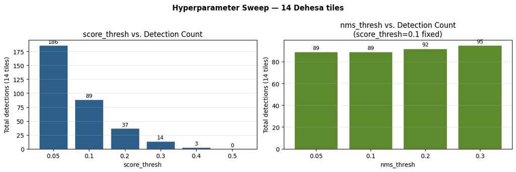

```
Saved: reports/sweep_results.png
```

```python
fig, axes = plt.subplots(1, 2, figsize=(12, 4))
fig.suptitle('Hyperparameter Sweep — 14 Dehesa tiles', fontsize=12, fontweight='bold')

ax = axes[0]
ax.bar(score_df['score_thresh'].astype(str), score_df['n_detections'],
       color='#2c5f8a', edgecolor='white')
for bar, val in zip(ax.patches, score_df['n_detections']):
    ax.text(bar.get_x() + bar.get_width()/2, bar.get_height() + 1,
            str(val), ha='center', va='bottom', fontsize=9)
ax.set(xlabel='score_thresh', ylabel='Total detections (14 tiles)',
       title='score_thresh vs. Detection Count')
ax.grid(alpha=0.3, axis='y')

ax = axes[1]
ax.bar(nms_df['nms_thresh'].astype(str), nms_df['n_detections'],
       color='#5d8a2c', edgecolor='white')
for bar, val in zip(ax.patches, nms_df['n_detections']):
    ax.text(bar.get_x() + bar.get_width()/2, bar.get_height() + 1,
            str(val), ha='center', va='bottom', fontsize=9)
ax.set(xlabel='nms_thresh', ylabel='Total detections (14 tiles)',
       title='nms_thresh vs. Detection Count\n(score_thresh=0.1 fixed)')
ax.grid(alpha=0.3, axis='y')

plt.tight_layout()
plt.savefig(REPORTS / 'sweep_results.png', dpi=150, bbox_inches='tight')
plt.show()
print('Saved: reports/sweep_results.png')
```

### Efecto visual de score_thresh en las detecciones

Cada fila es un valor de `score_thresh`. Cada columna es una de las 3 primeras imágenes Dehesa. Los cuadros rojos son los árboles detectados — observa cómo al bajar el umbral aparecen más detecciones (incluyendo falsos positivos) y al subirlo sólo quedan las más confiables.

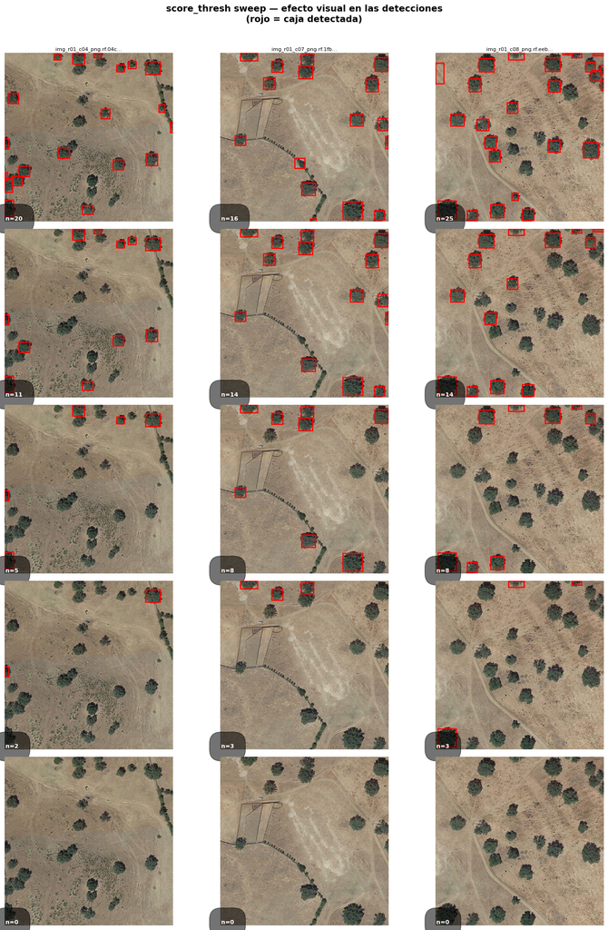

```
Saved: reports/sweep_visual.png
```

```python
SWEEP_THRESHOLDS = [0.05, 0.10, 0.20, 0.30, 0.40]
SAMPLE_IMGS      = test_images[:3]

# --- collect detections for each (thresh, image) pair ---
sweep_boxes = {}  # (thresh, img_path) -> DataFrame | None
for st in SWEEP_THRESHOLDS:
    model.model.score_thresh     = st
    model.config['score_thresh'] = st
    for img_path in SAMPLE_IMGS:
        sweep_boxes[(st, img_path)] = model.predict_image(path=str(img_path))

# restore
model.model.score_thresh     = _orig_score
model.config['score_thresh'] = _orig_score

# --- plot grid: rows = thresholds, cols = images ---
n_rows = len(SWEEP_THRESHOLDS)
n_cols = len(SAMPLE_IMGS)

fig, axes = plt.subplots(n_rows, n_cols, figsize=(5 * n_cols, 4 * n_rows))
fig.suptitle('score_thresh sweep — efecto visual en las detecciones\n'
             '(rojo = caja detectada)', fontsize=14, fontweight='bold', y=1.01)

for r, st in enumerate(SWEEP_THRESHOLDS):
    for c, img_path in enumerate(SAMPLE_IMGS):
        ax = axes[r, c]
        img = np.array(Image.open(img_path).convert('RGB'))
        ax.imshow(img)

        boxes = sweep_boxes[(st, img_path)]
        n_det = 0
        if boxes is not None and len(boxes) > 0:
            n_det = len(boxes)
            for _, row in boxes.iterrows():
                ax.add_patch(patches.Rectangle(
                    (row.xmin, row.ymin),
                    row.xmax - row.xmin, row.ymax - row.ymin,
                    linewidth=1.8, edgecolor='red', facecolor='none'))

        ax.axis('off')
        # column header only on first row
        if r == 0:
            ax.set_title(f'{img_path.name[:22]}…', fontsize=8, pad=4)
        # row label on the leftmost column
        if c == 0:
            ax.set_ylabel(f'score_thresh={st:.2f}', fontsize=10, rotation=0,
                          labelpad=110, va='center', fontweight='bold')
        # detection count in corner
        ax.text(4, img.shape[0] - 6, f'n={n_det}',
                color='white', fontsize=9, fontweight='bold',
                bbox=dict(facecolor='black', alpha=0.55, pad=2, boxstyle='round'))

plt.tight_layout()
plt.savefig(REPORTS / 'sweep_visual.png', dpi=130, bbox_inches='tight')
plt.show()
print('Saved: reports/sweep_visual.png')
```

## Conclusion

| Finding | Evidence |
| --- | --- |
| Domain shift is real | KS D >> 0, p < 0.0001 on both tests |
| Score distributions barely overlap | Median confidence drops from NEON to Dehesa |
| Threshold tuning cannot fix it | NMS sweep is flat; score_thresh tradeoff never reaches NEON levels |

**Next:** `02_annotation_evaluation.ipynb` — use the 14 ground-truth annotations to measure Precision, Recall, and F1 directly.